# Wybory - faza 2

Katarzyna Fąk, Justyna Jankowiak

09.04.2015

# Przygotowanie danych

Jak pobierałyśmy dane?

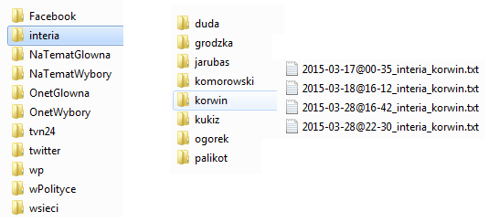

Po uporządkowaniu otrzymujemy dwa pliki (struktura podobna jak w danych `auta2012`)

- podsumowanie.txt
- artykuly.txt

### Podsumowanie

```r
podsumowanie <- read.csv("podsumowanie.txt")
podsumowanie[sample(1:nrow(podsumowanie), 5), ]
```

```
##               portal kandydat                data nr czy.w.tytule
## 2058 wPolityceGlowna     duda 2015-03-31 10:01:00  4         TRUE
## 3109 wPolityceGlowna   ogorek 2015-03-19 18:01:00  1        FALSE
## 1492           tvn24     duda 2015-04-05 20:42:00  2         TRUE
## 3229 wPolityceGlowna  palikot 2015-04-01 12:10:00  1        FALSE
## 1276      OnetWybory   korwin 2015-04-05 00:00:00  8        FALSE
##      dlugosc.art ile.razy ile.razy.wzg waga
## 2058        1147        3 0.0026155187    2
## 3109        2817        1 0.0003549876    2
## 1492        8400       10 0.0011904762    3
## 3229        5947        1 0.0001681520    2
## 1276        1332        1 0.0007507508    2
```

### Artykuły

Treść artykułu została oczyszczona

- usunięto stopwordsy (podstawowy słownik + własnoręcznie dodane)
- nazwiska i wyrazy “wyborcze” zostały sprowadzone do mianownika

```
##                                                       regex
## komorowski   (Komorowski(\\p{L})*)|((B|b)ronkobus(\\p{L})*)
## kowalski                   Marian(\\p{L})* Kowalsk(\\p{L})*
## duda                  (Dud(\\p{L})*)|((D|d)udabus(\\p{L})*)
## palikot                                     Paliko(\\p{L})*
## jarubas                                    Jarubas(\\p{L})*
## ogorek                                      Ogórek(\\p{L})*
## korwin                                      Korwin(\\p{L})*
## grodzka                        Ann(\\p{L})+ Grodzk(\\p{L})*
## wilk                         Jac(e)*(\\p{L})* Wilk(\\p{L})*
## braun                      Grzegorz(\\p{L})* Braun(\\p{L})*
## kukiz                                        Kukiz(\\p{L})*
## tanajno                                     Tanajn(\\p{L})*
## prezydent                                prezydent(\\p{L})*
## prezydenckie                            prezydenck(\\p{L})*
## andrzej                                    andrzej(\\p{L})*
## bronislaw                                   bronis(\\p{L})*
## kaczynski                                kaczyński(\\p{L})*
## kandydat                                   kandyda(\\p{L})*
## wybory                                       wybor(\\p{L})*
## kampania                                   kampani(\\p{L})*
## janusz                                      janusz(\\p{L})*
## polska                                        pols(\\p{L})*
## polacy                                   pola(k|c)(\\p{L})*
## adam                                          adam(\\p{L})*
## podpisy                                     podpis(\\p{L})*
```

```r
artykuly <- read.csv("artykuly.txt")
artykuly[200,]
```

```
##            portal kandydat                data nr
## 200 NaTematWybory   korwin 2015-03-15 00:00:00  1
##                                                                                                                                                                                                                                                                                                          …
## 200  janusz korwin    kandydat  kandydat  pełnoprawny  pierwszy zarejestrowany kandydat rozpoczyna nowy etap kampania •  adam stępień  agencja ga kampania prezydenckie oficjalnie rozpoczął  sobotę janusz korwin    charakterze „kandydat  kandydat”   pełnoprawny  pierwszy zarejestrowany aspirant  p…
```

# Wskaźniki

## Sumaryczne wagi artykulow

> IDEA: Funkcja zwraca tabelkę wszystkich kandydatów z sumarycznymi wagami unikatowych artykulów. Jedna z funkcji zrobi to bez rozrozniania portali, druga z rozroznieniem portali

```r
sumaryczna_waga()
```

```
## komorowski       duda     korwin     ogorek      kukiz    palikot    jarubas   kowalski    grodzka
##       1388       1036        306        292        262        237        152         96         84
##       wilk      braun    nowicka
##         66         54          4
```

```r
sumaryczna_waga("wp")
```

```
## komorowski       duda      kukiz     ogorek     korwin    jarubas    palikot    nowicka
##         46         22         17         15         14          4          4          1
```

```r
sumaryczna_waga_szczegolowa()
```

```
##                 braun duda grodzka jarubas komorowski korwin kowalski kukiz nowicka ogorek palikot
## interia             0   34       2       2         44      6        0     4       0     10       2
## NaTematGlowna       0   60       4       6         70     16        2    24       0     14      16
## NaTematWybory       6  178      16      16        202     62       12    60       0     76      58
## OnetGlowna         11   67      12      23         81     39       15    30       0     29      29
## OnetWybory         20  100      32      46        132     60       40    42       0     42      38
## tvn24               0  112       3       0        134     10        0    16       0     50      21
## wp                  0   22       0       4         46     14        0    17       1     15       4
## wPolityceGlowna    17  421      15      55        659     99       27    69       0     56      69
## wsieci              0   42       0       0         20      0        0     0       3      0       0
##                 wilk
## interia            0
## NaTematGlowna      0
## NaTematWybory      8
## OnetGlowna        13
## OnetWybory        34
## tvn24              0
## wp                 0
## wPolityceGlowna   11
## wsieci             0
```

```r
sumaryczna_waga_szczegolowa(strona=c("wp","interia"))
```

```
##         braun duda grodzka jarubas komorowski korwin kowalski kukiz nowicka ogorek palikot wilk
## wp          0   22       0       4         46     14        0    17       1     15       4    0
## interia     0   34       2       2         44      6        0     4       0     10       2    0
```

## Ile razy można było przeczytać o danym kandydacie

Zliczane sa tu wszystkie - jak leci - nazwiska. Co jesli artykul sie powtarzal? Nie szkodzi. Tu interesuje nas czy gdy sie weszlo o danej godzinie do internetu, to czy mozna bylo o kandydacie poczytać.

```r
ilosciowo_kandydaci()
```

```
## .
## komorowski       duda     korwin      kukiz     ogorek    palikot    jarubas   kowalski    grodzka
##       1190        986        260        248        218        186        133         92         64
##       wilk      braun    nowicka
##         57         37         25
```

## Przegląd nagłówków

Funkcja zlicza ile razy w naglowku wystapilo nazwisko danego kandydata. Nie uwgledniamy unikatowych artykulow ale to, czy gdy sie weszlo o dowolnej porze do internetu nazwisko kandydata uderzalo nas po oczach ze wszystkich wokolo naglowkow.

```r
# ze wszystkich portali:
przeglad_naglowkow()
```

```
##                 braun duda grodzka jarubas komorowski korwin kowalski kukiz nowicka ogorek palikot
## interia             0   24       1       2         25      4        0     2       0      9       1
## NaTematGlowna       0   22       0       2         22      6        0     9       0      1       6
## NaTematWybory       0   58       0       4         57     14        0    12       0     21      13
## OnetGlowna          0   31       1       1         25      5        0    10       0      1       3
## OnetWybory          0   21       3       5         41     12        8     4       0      4       4
## tvn24               0   61       1       0         65      5        0     8       0     24       9
## wp                  0   38       0       2         36     11        0    28       0     11       2
## wPolityceGlowna     7  265       0      25        487     32        9    47       0     10      30
## wsieci              0  160       0       0         58      0        0     0       0      0       0
##                 wilk
## interia            0
## NaTematGlowna      0
## NaTematWybory      0
## OnetGlowna         0
## OnetWybory         3
## tvn24              0
## wp                 0
## wPolityceGlowna    0
## wsieci             0
```

```r
# z wybranych portali:
przeglad_naglowkow(strona=c("tvn24","wsieci"))
```

```
##        braun duda grodzka jarubas komorowski korwin kowalski kukiz nowicka ogorek palikot wilk
## tvn24      0   61       1       0         65      5        0     8       0     24       9    0
## wsieci     0  160       0       0         58      0        0     0       0      0       0    0
```

## Istnienie kandydata w sieci

Funkcja ma pokazywac istnienie kandydata w czasie i na portalu, tzn. w jakim czasie można było o kandydacie najwięcej poczytać. O którym kandydacie najwięcej. Jak zmieniała się tendencja. Dlatego nie jest ważne, że te same artykuły moga się powielać: istotą jest, czy w ogóle kandydat istniał.

Problemem tutaj (i wszędzie tak naprawdę) jest to, ze brak punktu nie oznacza, że o kandydacie nie pisano. Wszak moze byc, ze nie bylo pobierania o danej porze.

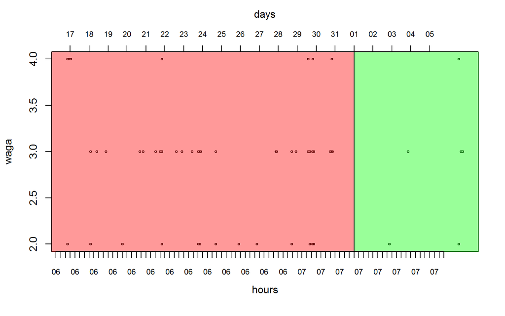

```r
# proste dzialanie
istnienie_kandydata(osoba="komorowski", strona="tvn24", po_czym = "waga")
```

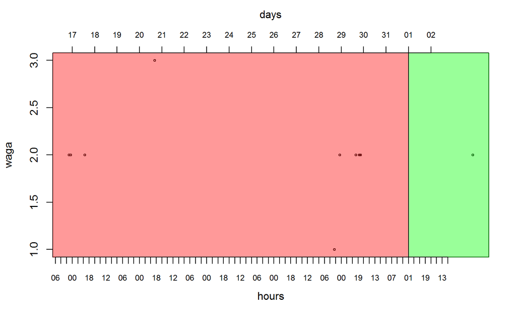

```r
#

istnienie_kandydata(osoba="korwin", strona="wp")
```

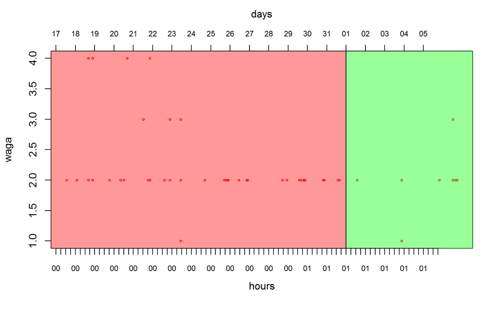

```r
# dwa portale
istnienie_kandydata(osoba="komorowski", strona=c("wp","interia"), kolor="red")
```

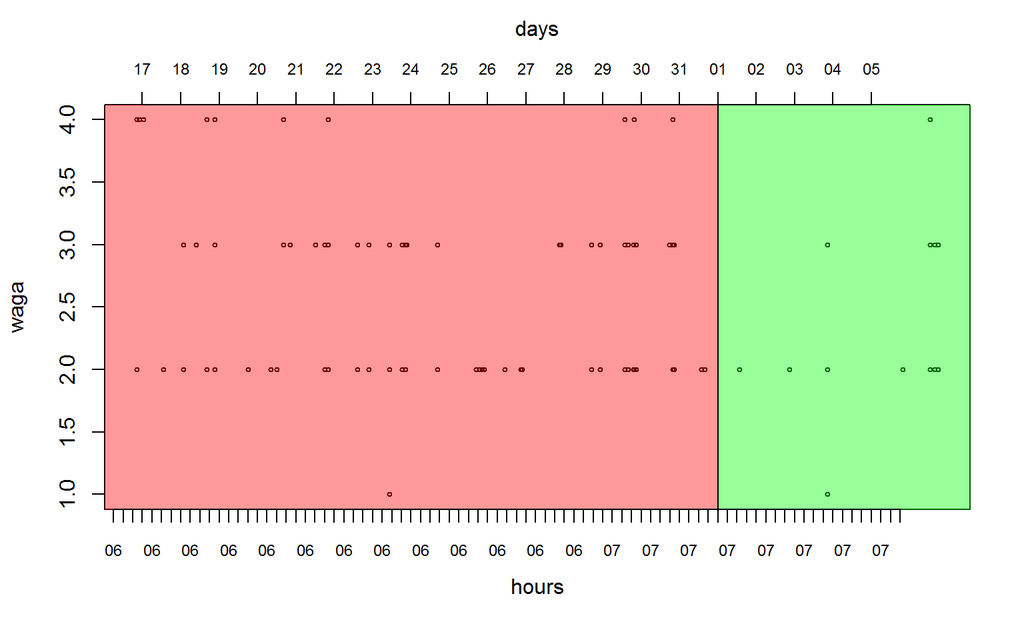

```r
# TRZY portale :D
istnienie_kandydata(osoba="komorowski", strona=c("wp","interia","tvn24"))
```

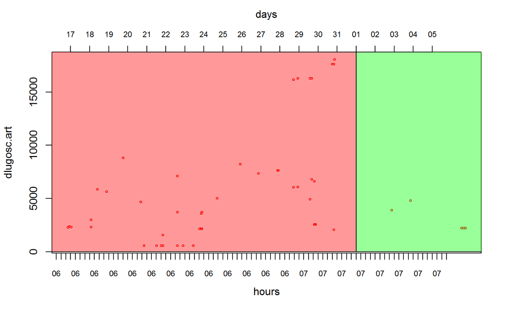

```r
# inny wskaźnik
istnienie_kandydata(osoba="komorowski", strona="tvn24", kolor="red", po_czym = "dlugosc.art")
```

## Liczba artykułów

Funkcja rysuje wykres ilosci artykulow o danym kandydacie kazdego dnia. Opcjonalne jest ustawienie portali, ktorych dane nas interesują. Zliczane są artykuly UNIKATOWE, różne teksty o kandydacie: nie interesuje nas tutaj jak dlugo dany artykul wisiał na stronie. Jako różne traktujemy dwa artykuly o tej samej treści, jednak pochodzących z różnych miejsc na stronie.

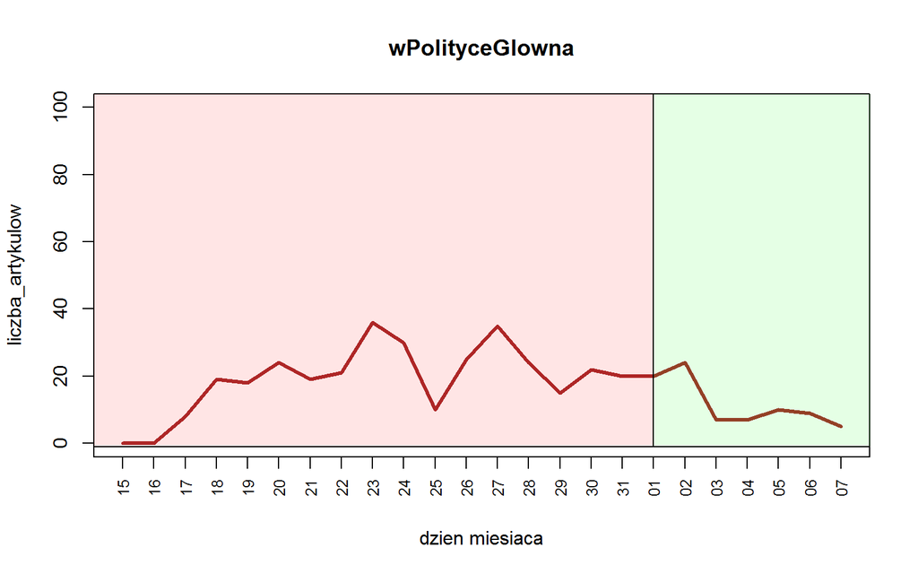

```r
# przyklad bez NAs
ile_artykulow(osoba="duda",strona="wPolityceGlowna")
```

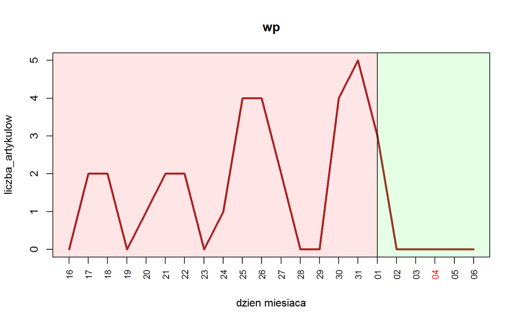

```r
ile_artykulow(osoba="duda",strona="wp", ylim=c(0,5))
```

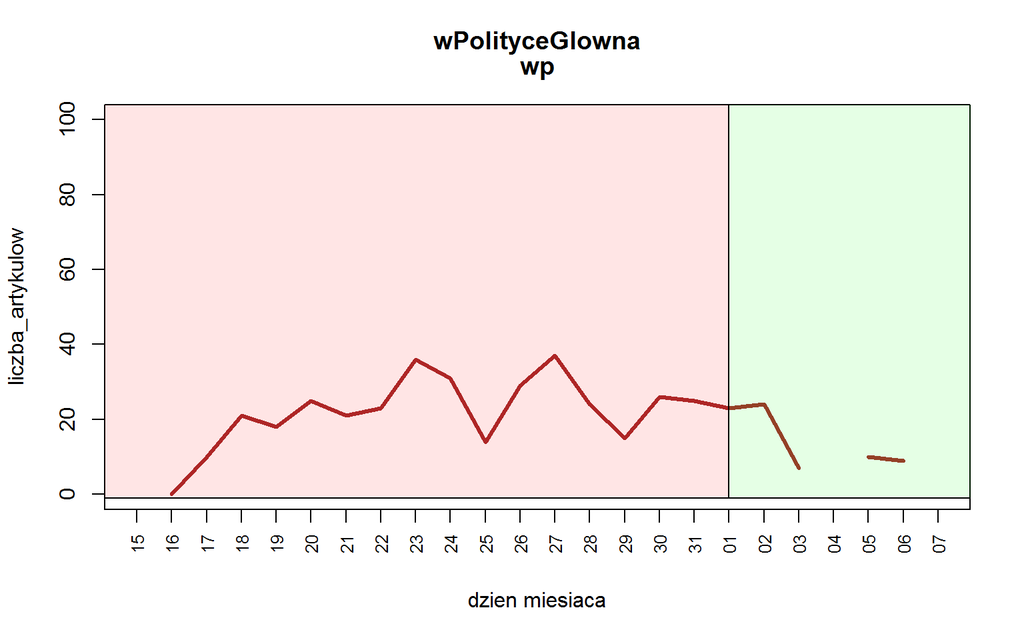

```r
# obsluga NAs
ile_artykulow(osoba="duda",strona=c("wPolityceGlowna","wp"))
```

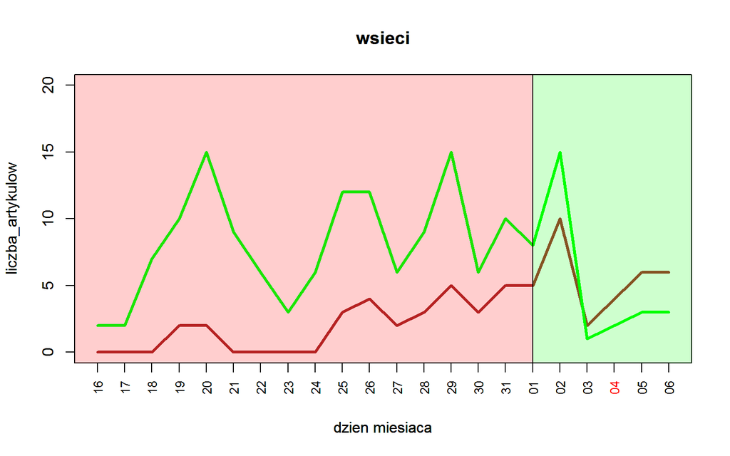

```r
# Łączenie wykresów.
ile_artykulow(osoba="komorowski","wsieci", ylim=c(0,20))
par(new=TRUE)
ile_artykulow(osoba="duda", "wsieci", kolor="green", ylim=c(0,20))
```

# Cloudy

Dla scalonych artykułów (wszystkich lub filtorwanych względem portalu/kandydata) dla określonej liczby najczęstszych słów.

#### Dla wszystkich danych

[figure not shown]

```
## words
##  prezydent     polska komorowski       duda     wybory   kandydat  bronislaw    andrzej   kampania
##       3473       3162       3085       2418       2345       2115       1343       1333       1329
##        pis
##       1274
```

```r
zrobChmure(artykuly, ile.slow=100)
```

#### Dla kandydatów w tym samym portalu

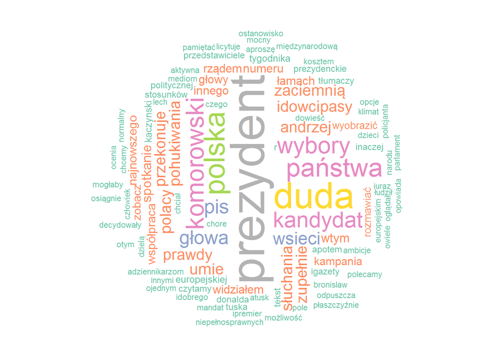

```
## words
##  prezydent       duda     polska    państwa komorowski     wybory   kandydat        pis      głowa
##         60         44         34         30         28         26         24         21         20
##     wsieci
##         18
```

```r
zrobChmure(artykuly, port="wsieci", kand="duda", ile.slow=100)
```

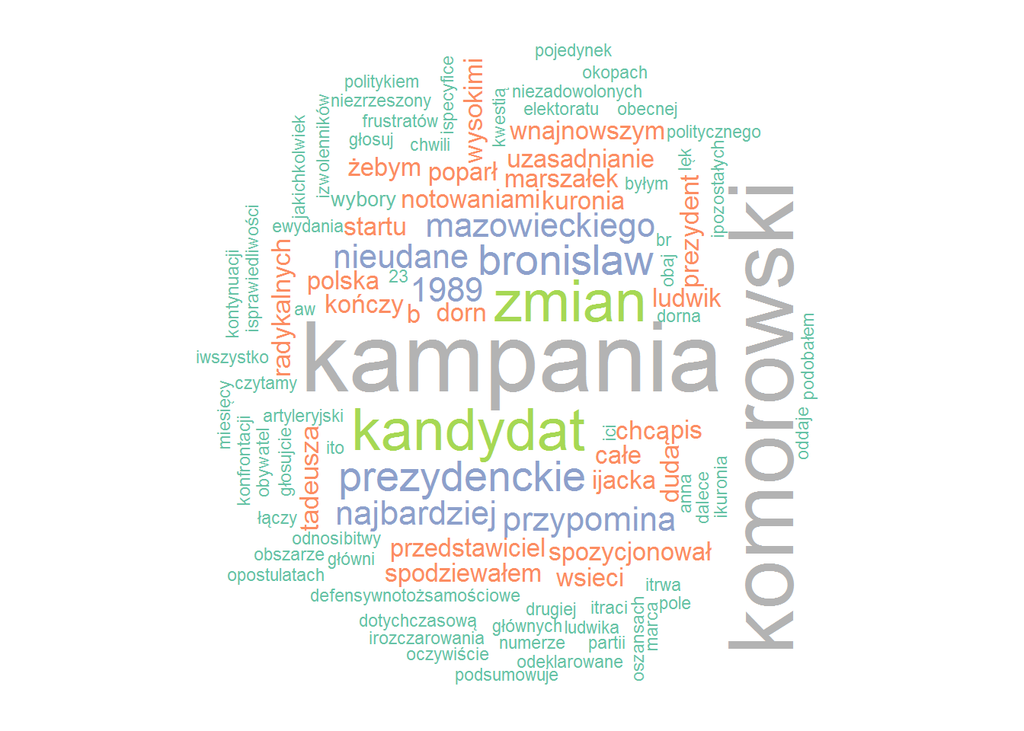

```
## words
##      kampania    komorowski      kandydat         zmian     bronislaw  prezydenckie          1989
##            33            30            18            18            12            12             9
## mazowieckiego   najbardziej      nieudane
##             9             9             9
```

```r
zrobChmure(artykuly, port="wsieci", kand="komorowski", ile.slow=100)
```

#### Ile kandydata w artykule o nim?

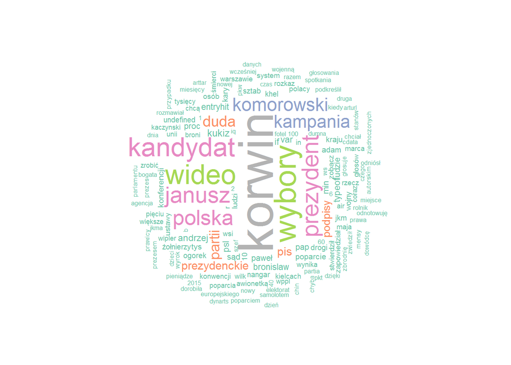

```
## words
##     korwin     wybory      wideo   kandydat  prezydent     janusz     polska komorowski   kampania
##        198        117        101         98         83         80         75         61         58
##       duda
##         47
```

```r
zrobChmure(artykuly, kand="korwin")
```

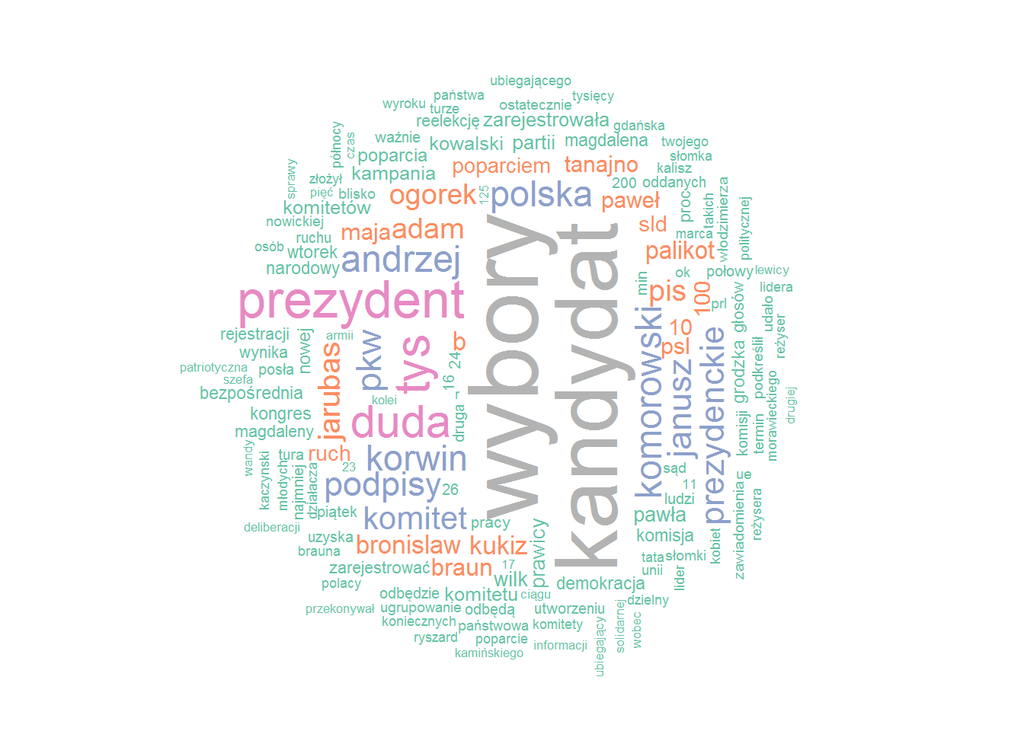

```
## words
##     wybory   kandydat  prezydent        tys       duda    andrzej komorowski     korwin     polska
##        210        185        101         90         85         65         65         62         62
##        pkw
##         61
```

```r
zrobChmure(artykuly, kand="braun")
```

# Portale spolecznosciowe

## Twitter

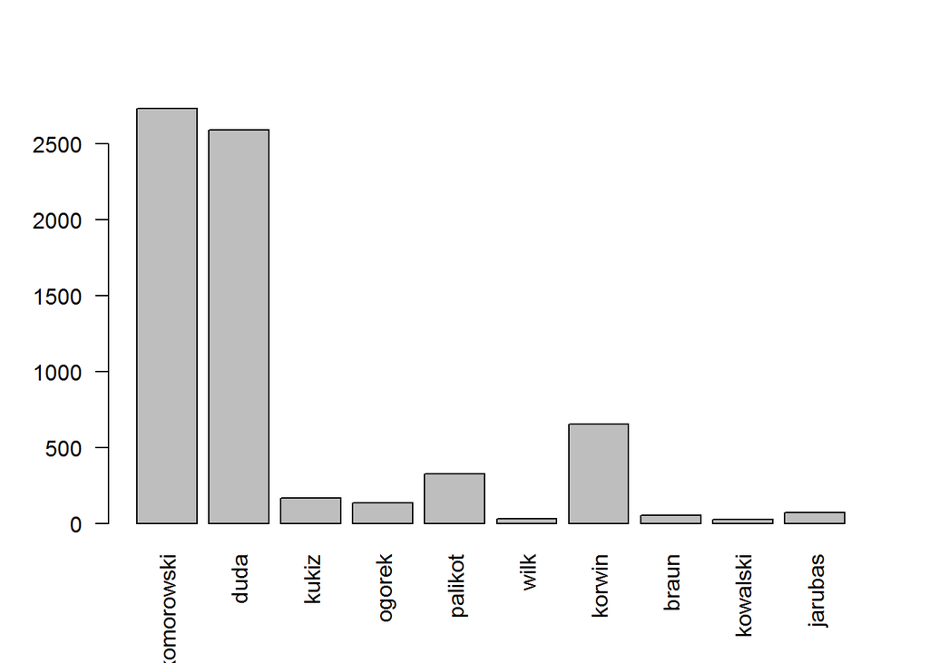

# Kody

Tworzenie tabel podsumowanie.txt

```r
# pobierzDane <- function(portal, x){
#    kod1 <- c("NaTematGlowna", "NaTematWybory", "OnetGlowna", "OnetWybory", "wPolityceGlowna")
#    kod2 <- c("interia", "tvn24", "wp", "wsieci")
#    if(portal %in% kod1) dane <- read.csv(x)
#    if(portal %in% kod2) dane <- read.csv(x, encoding = "UTF-8")
#    return(dane)
# }
#
# znajdzKolumny <- function(portal, dane){
#    if(portal %in% c("NaTematGlowna", "NaTematWybory", "OnetWybory")){
#       tytul <- dane[, 1]
#       artykul <- dane[, 3]
#       typ <- rep("brak", nrow(dane))
#    }
#    if(portal %in% c("OnetGlowna")){
#       tytul <- dane[, 1]
#       artykul <- dane[, 2]
#       typ <- dane[, 4]
#    }
#    if(portal %in% c("interia", "wp", "wsieci")){
#       tytul <- dane[, 2]
#       artykul <- dane[, 3]
#       typ <- dane[, 1]
#    }
#    if(portal == "tvn24"){
#       tytul <- dane[, 3]
#       artykul <- dane[, 4]
#       typ <- dane[, 1]
#    }
#    if(portal == "wPolityceGlowna"){
#       tytul <- dane[, 1]
#       artykul <- dane[, 5]
#       typ <- dane[, 4]
#    }
#    return(list(tytul, artykul, typ))
# }
#
# nadajDate <- function(nazwa){
#    czy.z.godzina <- stri_detect_fixed(nazwa, "@")
#    if(czy.z.godzina == TRUE){
#       data <-  as.character(strptime(nazwa, "%F@%H-%M"))
#    } else {
#       data <- as.character(strptime(nazwa, "%F"))
#       data <- paste(data, "00:00:00")
#    }
#    return(data)
# }
#
# nadajWage <- function(portal, typ){
#    n <- length(typ)
#    waga <- numeric(n)
#    if(typ[1]=="brak"){ #OnetWybory, #NaTematGlowna, #NaTematWybory
#       waga <- rep(2, n) #taka sama wszedzie
#    }
#    if(portal=="interia"){
#       waga[typ=="duży news"] = 4
#       waga[typ=="obrazki duze"] = 3
#       waga[typ=="newsy"] = 2
#    }
#    if(portal=="OnetGlowna"){
#       waga[typ=="duze"] = 4
#       waga[typ=="srednie"] = 3
#       waga[typ=="male"] = 2
#    }
#    if(portal=="tvn24"){
#       waga[typ=="newsy"] = 2
#       waga[typ=="obrazki"] = 3
#       waga[typ=="maintopic"] = 4
#    }
#    if(portal=="wp"){
#       waga[typ=="main topic"] = 4
#       waga[typ=="news"] = 2
#       waga[typ=="obrazki"] = 3
#       waga[typ=="male obrazki"] = 1
#    }
#    if(portal=="wPolityceGlowna"){
#       waga[typ=="top"] = 4
#       waga[typ=="top2"] = 4
#       waga[typ=="duze"] = 3
#       waga[typ=="srednie"] = 2
#       waga[typ=="male"] = 2
#       waga[typ=="mini"] = 1
#    }
#    if(portal=="wsieci"){
#       waga[typ=="glowna"] = 4
#       waga[typ=="obrazki"] = 3
#    }
#    return(waga)
# }
#
#
# ############################################################################
# # dla danego folderu typu np. interia/komorowski robimy ramke danych
# # z plików, które nie były jeszcze dołączone
# ############################################################################
#
# zrobListeRamekPortalKandydat <- function(pliki){
#    regexy <- c(
#       "(Komorowski(\\p{L})*)|((B|b)ronkobus(\\p{L})*)",
#       "Marian(\\p{L})* Kowalsk(\\p{L})*",
#       "(Dud(\\p{L})*)|((D|d)udabus(\\p{L})*)",
#       "Paliko(\\p{L})*",
#       "Jarubas(\\p{L})*",
#       "Ogórek",
#       "Korwin(\\p{L})*",
#       "Ann(\\p{L})+ Grodzk(\\p{L})*",
#       "Jac(e)*(\\p{L})* Wilk(\\p{L})*",
#       "Grzegorz(\\p{L})* Braun(\\p{L})*",
#       "Kukiz(\\p{L})*",
#       "Tanajn(\\p{L})*"
#    )
#
#    names(regexy) <- c("komorowski", "kowalski", "duda", "palikot", "jarubas", "ogorek",
#                       "korwin", "grodzka", "wilk", "braun", "kukiz", "tanajno")
#
#    lista.ramek.portal.kandydat <- lapply(pliki, function(x){
#
#       portal <- stri_extract_first_regex(x, "(?<=_)[^_]+")
#       kandydat <- stri_extract_last_regex(x, "(?<=_)[^(\\.|_)]+")
#
#       dane <- pobierzDane(portal, x)
#       n <- nrow(dane)
#       kolumny <- znajdzKolumny(portal, dane)
#
#       #data artykułu (przyjmujemy dla ujednolicenia, że data artykułu to data jego pobrania)
#       kiedy <- nadajDate(x)
#       data <- rep(kiedy, n)
#       #nr artykułu (w danym pliku, czyli w danym dniu i ewentualnie o danej godzinie)
#       nr <- c(1:n)
#       #czy nazwisko kandydata pojawia sie w tytule artykulu
#       regex <- paste("(?i)", regexy[kandydat], sep="")
#       czy.w.tytule <- stri_detect_regex(kolumny[[1]], regex)
#       #długość artykułu
#       tresc <- as.character(kolumny[[2]])
#       dlugosc.art <- nchar(tresc)
#       #ile razy w artykule pojawia się regex kandydata
#       ile.razy <- stri_count_regex(tresc, regex)
#       #częstość występowania regexa w artykule
#       ile.razy.wzg <- ile.razy/dlugosc.art
#       #waga artykulu
#       typ <- kolumny[[3]]
#       waga <- nadajWage(portal, typ)
#
#       #ramka danych dla pojedynczego pliku
#       ramka.plik <- data.frame(portal, kandydat, data, nr, czy.w.tytule, dlugosc.art, ile.razy,
#                                ile.razy.wzg, waga, stringsAsFactors=FALSE)
#       return(ramka.plik)
#    })
#    return(lista.ramek.portal.kandydat)
# }
#
#
# zrobJednaRamkePortalKandydat <- function(dataFrameList){
#    n <- length(dataFrameList)
#    if (n==1){
#       return(dataFrameList[[1]])
#    } else {
#       tmpDataFrame <- dataFrameList[[1]]
#       for (i in 2:n){
#          bindDataFrames <- rbind(tmpDataFrame, dataFrameList[[i]])
#          tmpDataFrame <- bindDataFrames
#       }
#       return(tmpDataFrame)
#    }
# }
#
#
# ############################################################################
# # odpalanie funkcji powyżej
# ############################################################################
#
# #ustawianie ścieżki do folderu z danymi
# setwd("D:/GoogleDrive/Studia/SemestrVIII/R-i-Big-Data/Wybory/dane")
# glowna <- getwd()
#
# #szukamy scieżek do folderów portal/kandydat
# foldery.all <- list.dirs(full.names = FALSE)
# ktore.nietwitter <- !stri_detect_regex(foldery.all, "twitter")
# ktore.niefacebook <- !stri_detect_regex(foldery.all, "(?i)facebook")
# ktore.nieglowne <- stri_detect_regex(foldery.all, "/")
# #lista folderów dla poszczególnych kandydatów z danych portali
# #(z wyłączeniem twittera i facebooka)
# foldery <- foldery.all[ktore.nietwitter & ktore.niefacebook & ktore.nieglowne]
#
# a <- list()
# if(!file.exists("podsumowanie.txt")){
#
#    for (i in seq_along(foldery)){
#       sciezka <- foldery[i]
#       setwd(file.path(glowna, sciezka))
#       pliki.all <- list.files()
#       if(length(pliki.all) > 0) {
#          a[[i]] <- zrobJednaRamkePortalKandydat(zrobListeRamekPortalKandydat(pliki.all))
#       }
#       setwd(glowna)
#    }
#    b <- zrobJednaRamkePortalKandydat(a)
#    write.table(b, "podsumowanie.txt", row.names=FALSE, sep=",")
#
# } else {
#
#    #wczytujemy plik podsumowanie, do którego będziemy dołączać kolejne wiersze
#    podsumowanie <- read.csv("podsumowanie.txt")
#    for (i in seq_along(foldery)){
#       sciezka <- foldery[i]
#       print(sciezka)
#       setwd(file.path(glowna, sciezka))
#
#       portal.tmp <- stri_extract_first_regex(sciezka, "[^/]+")
#       kandydat.tmp <- stri_extract_last_regex(sciezka, "[^/]+")
#
#       #niestety dla jednego portalu mamy małą rozbieżność nazw
#       if(portal.tmp == "wPolityce") portal.tmp <- "wPolityceGlowna"
#
#       #maksymalna data dla portalu i kandydata w pliku podsumowanie.txt
#       portalKandydat <- podsumowanie %>%
#          filter(portal == portal.tmp, kandydat == kandydat.tmp)
#       if(nrow(portalKandydat) == 0) next
#
#       max.data <- portalKandydat %>%
#          summarise(max.data = max(strftime(data, "%F %T")))
#       max.data <- as.character(max.data)
#       max.data <- strptime(max.data, "%F %T")
#
#       #szukamy plików z datą młodszą niż znaleziona w pliku
#       #i tylko dane z tych plików dołączamy do obecnych danych
#       pliki.all <- list.files()
#       n <- length(pliki.all)
#       if(n == 0) next
#
#       #sprawdzamy czy pliki są z godziną czy bez (sama data)
#       ost <- pliki.all[n]
#       czy.godzina <- stri_detect_regex(ost, "@")
#       if(czy.godzina == TRUE){
#          data.pliku <- strptime(ost, "%F@%H-%M")
#          indeksy.nowe <- logical(n)
#          while(data.pliku - max.data > 0){
#             indeksy.nowe[n] <- TRUE
#             n <- n - 1
#             if (n == 0) next
#             plik.tmp <- pliki.all[n]
#             data.pliku <- strptime(plik.tmp, "%F@%H-%M")
#          }
#       } else {
#          data.pliku <- strptime(ost, "%F")
#          indeksy.nowe <- logical(n)
#          while(data.pliku - max.data > 0){
#             indeksy.nowe[n] <- TRUE
#             n <- n - 1
#             if (n == 0) next
#             plik.tmp <- pliki.all[n]
#             data.pliku <- strptime(plik.tmp, "%F")
#          }
#       }
#
#       #nazwy nowych plikow
#       pliki <- pliki.all[indeksy.nowe]
#
#       if(length(pliki) > 0) {
#          a[[i]] <- zrobJednaRamkePortalKandydat(zrobListeRamekPortalKandydat(pliki))
#       }
#       setwd(glowna)
#    }
#    if(length(a) > 0){
#       b <- zrobJednaRamkePortalKandydat(a)
#       write.table(b, "podsumowanie.txt", row.names=FALSE, col.names = FALSE,
#                   append=TRUE, sep=",")
#    }
# }
```

## Sumowanie wag

```r
sumaryczna_waga <- function(strona=all){
      require(dplyr)
      dane <- read.csv("prezentacja2/podsumowanie.txt")

      # wybranie unikatowych artykulow. Czasem zdarza sie ten sam artykul w sekcji newsy i obrazek
      # wowczas wydaje sie uzasadnionym traktowac te rekordy jako rozne. Usuwamy zatem te same artykuly,
      # ktore zostaly wielokrotnie pobrane. Jako wyznacznik identycznosci artykulow traktuje
      # liczbe znakow w nim zawarta.
      dane %>%
            filter(portal%in%strona) %>%
            select(portal,kandydat,dlugosc.art,waga) %>%
            unique -> df
      return( sort(tapply(df$waga,df$kandydat,sum), decreasing = TRUE) )
}

sumaryczna_waga_szczegolowa <- function(strona=all){
      require(dplyr)
      dane <- read.csv("prezentacja2/podsumowanie.txt")

      # wybranie unikatowych artykulow. Czasem zdarza sie ten sam artykul w sekcji newsy i obrazek
      # wowczas wydaje sie uzasadnionym traktowac te rekordy jako rozne. Usuwamy zatem te same artykuly,
      # ktore zostaly wielokrotnie pobrane. Jako wyznacznik identycznosci artykuolow traktuje
      # liczbe znakow w nim zawarta.
      dane %>%
            filter(portal%in%strona) %>%
            select(portal,kandydat,dlugosc.art,waga) %>%
            unique -> df
      wynik <- sapply(split(df,df$kandydat), function(x) tapply(x$waga,x$portal,sum))
      wynik <- replace(wynik,is.na(wynik),0)  # usuwanie NAs. W tym przypadku oznaczaja one zerowa wage.
      return( wynik[strona,] )
      }
```

## Ilościowo kandydaci

```r
ilosciowo_kandydaci <- function(){
      require(dplyr)
      dane <- read.csv("prezentacja2/podsumowanie.txt")
      dane %>%
            select(kandydat) %>%
            table %>%
            sort(decreasing = TRUE)
      }
```

## Istnienie kandydata

```r
istnienie_kandydata <- function(osoba,strona,kolor="black",po_czym="waga"){
      require(dplyr)
      dane <- read.csv("prezentacja2/podsumowanie.txt")
      dane %>%
            filter(portal%in%strona,kandydat==osoba) %>%
            select(kandydat,portal,data,contains(po_czym)) -> df2
      if( nrow(df2)>0 ){
            as.POSIXct(df2$data) -> df2$data

            # dla czytelnosci zamiast ustawiac miesiace w labels podzielimy obszar wykresu na miesiace:
            kwiecien <- as.POSIXct("2015-04-01 01:00:00")
            maj <- as.POSIXct("2015-05-01 01:00:00")
            # pelna os czasu
            date_range <- strptime( range(df2$data), format="%F" )
            hour_axis <- seq( date_range[1], date_range[2], by = "hour" )
            day_axis <- seq( date_range[1], date_range[2], by = "day" )

            plot( df2$data,t(df2[po_czym]), xaxt="n", type="p", pch=1, cex=.5, col=kolor,xlab="", ylab=po_czym)
            rect(0,-1,kwiecien,1000000,col=rgb(1,0,0,0.4),border = NULL)
            rect(kwiecien,-1,maj,1000000,col=rgb(0,1,0,.4), border=NULL)
            axis.POSIXct(side=1, at=hour_axis[rep(c(T,F,F,F,F,F),2)],
                         format="%H",las=1, cex.axis=0.75, )
            axis.POSIXct(side=3, at=day_axis,
                         format="%d",las=1, cex.axis=0.75, "days")
            mtext(side=1, "hours", line=2.5)
            mtext(side=3, "days", line=2.5)
      }else{
            cat("brak informacji o kandydacie")
      }
}
```

## Przegląd nagłówków

```r
przeglad_naglowkow <- function(strona=all){
      require(dplyr)
      dane <- read.csv("prezentacja2/podsumowanie.txt")
      dane %>%
            filter(portal%in%strona) %>%
            select(portal,kandydat,czy.w.tytule) %>%
            as.data.frame  %>%
            split(.$kandydat) %>%
            sapply(function(ramka_z_danej_strony)
                  table(ramka_z_danej_strony$portal[ramka_z_danej_strony$czy.w.tytule])
                  ) -> df
      return( df[strona,] )
}
```

## Ile artykułów

```r
ile_artykulow <- function( osoba, strona=all, kolor="brown", ylim=c(0,100) ){
      require(dplyr)
      require(stringi)
      dane <- read.csv("prezentacja2/podsumowanie.txt")

      #wybierzemy unikalne artykuly (kluczem unikalnosci bedzie liczba znakow w artykule: dlugosc.art.)
      df <- dane %>%
                  filter(portal%in%strona, kandydat==osoba) %>%
                  select(portal,kandydat,data,dlugosc.art) %>%
                  unique
      df$day <- as.Date(df$data)
      # UWAGA! nie ma wszystkich dat: jesli danego dnia byla sesja w ktorej nie znaleziono
      # artykulu, powinnismy miec 0 artykulow, jesli nie bylo sesji danego dnia mamy NA.
      # Pobieranie przebiegalo w trzech roznych trybach, na dwoch roznych systemach operacyjnych.
      win1 <- c("NaTematGlowna","OnetGlowna","wPolityceGlowna")
      lin <- c("wp","interia","wsieci","tvn24")
      # dlatego nalezy rozroznic wprowadzone przez uzytkownika strony.

      ########### FUNKCJE POMOCNICZE ###########
      dni_sesji_trybu <- function(tryb){
            dane %>%
                  filter(portal%in%tryb) %>%
                  select(data) %>%
                  t  %>%
                  as.Date  %>%
                  unique
      }
      agregacja_dniami <- function(tryb){
            df %>%
                  filter(portal%in%strona[strona%in%tryb]) %>%
                  group_by( czas = day ) %>%
                  summarise( liczba_artykulow = length(data) )
            # jest length(data) ale może byc (length( dowolna_kolumna )).
            # chodzi o liczbe rekordow w danym przedziale czasu.
      }
      uzupelnij_zerami <- function(tryb){
            df_trybu <- data.frame(czas2=dni_sesji_trybu(tryb))
            agregacja_dniami(tryb) %>% right_join(df_trybu, by=c("czas" = "czas2")) -> newdf
            newdf[is.na(newdf)] <- 0
            return( arrange(newdf,czas) )
      }
      #########################################

      if( any(strona%in%win1) ){
            a <- uzupelnij_zerami(win1)
            if( any(strona%in%lin) ){
                  b <- uzupelnij_zerami(lin)
                  # poniewaz podany parametr strona zawiera portale z dwoch roznych trybow,
                  # nalezy zsumowac liczbe artykulow zagregowana w dwoch roznych trybach.
                  # zrobimy to na "zjoinowanej" po czasie tabeli.
                  # zalozenie: sesje windowsa zawieraja sesje linuksa. i to jest prawda poki co.
                  c <- full_join(a,b, by="czas") %>% transmute(czas,liczba_artykulow=liczba_artykulow.x+liczba_artykulow.y)
                  d <- as.data.frame(c)
            } else {
                  d <- as.data.frame(a)
            }
      }else{
            d <- as.data.frame(uzupelnij_zerami(lin))
      }

      # pelna os czasu
      date_range <- range(as.Date(dane$data))
      day_axis <- seq( date_range[1], date_range[2], by = "day" )
      # hour_axis <- seq( date_range[1], date_range[2], by = "hour" )

      # plotowanie
      # dla czytelnosci zamiast ustawiac miesiace w labels podzielimy obszar wykresu na miesiace:
      kwiecien <- as.Date("2015-04-01")
      maj <- as.Date("2015-05-01")
      plot(liczba_artykulow ~ czas, d,
           type="l", lwd=3, col=kolor, xaxt="n", ylim=ylim, xlab="dzien miesiaca"
           , main=if(all(strona==all)) "all" else strona
           )
      rect(0,-1,kwiecien,200,col=rgb(1,0,0,.1),border = NULL)
      rect(kwiecien,-1,maj,200,col=rgb(0,1,0,.1), border=NULL)
      axis.Date(1, at = day_axis[day_axis%in%d$czas], las=2, format="%d", cex.axis=.8)
      axis.Date(1, at = day_axis[!(day_axis%in%d$czas)], las=2, format="%d", col.axis="red", cex.axis=.8)  # na czerwono braki danych

}
```

Funkcja do tworzenia chmury słów i tabelki z najczęstszymi wyrazami

```r
#na razie rozwazam tylko filtrowanie po portalu i kandydacie
#w kolejnej fazie weźmiemy również pod uwagę jak to się zmienia czasowo
#domyślnie do chmury bierzemy 150 njczęstszych słów
#i - kolumna w której znajduje się treść (funkcja aplikuje sie również do twittow czy facebooka)
zrobChmure <- function(art, port="", kand="", czas=c(),
                       ile.slow=150, i=5){
   if(port != "") art <- art %>% filter(portal == port)
   if(kand != "") art <- art %>% filter(kandydat == kand)

   tresc <- art[, i]
   words <- unlist(stri_extract_all_words(tresc))
   tab <- table(words)
   tab.sort <- sort(tab, dec=TRUE)
   do.chmury <- tab.sort[1:ile.slow]

   pal2 <- brewer.pal(8,"Set2")
   wordcloud(names(do.chmury), do.chmury, scale=c(5.5, 0.4), max.words=Inf,
             random.order=F, rot.per=.3, colors=pal2)
   tab.podst <- tab.sort[1:10]
   return(tab.podst)
}
```